# metagene analysis for m6A demo - Mathieu Flamand

#2020-05-01 ### Demo on metagene analysis plotting for m6A datasets #based on metaPlotR ‘https://github.com/olarerin/metaPlotR’ with some modification

#you will need the following libraries

to install you can run: install.packages(“tidyverse”) # ggplot comes with tidyverse, no need to reinstall. install.packages(“grid”) install.packages("scales)

this only needs to be done the first time, unless you installed a new version of R

```r
library(tidyverse)
library(ggplot2)
library(grid)
library(scales)
```

#First we read the input data from perl and store it in m6a.dist

```r
#read tab delim file
m6a.dist<-read.delim("annot_m6A.final.sorted.dist.measures.txt", header = T)
# we can further inspect the data stored in m6a.dist
dim(m6a.dist)
```

```
[1] 20903    14
```

```r
head(m6a.dist, 10)
```

|  | chr | coord | gene_name | refseqID | rel_location | utr5_st | utr5_end | cds_st | cds_end | utr3_st | utr3_end | utr5_size | cds_size | utr3_size |
| --- | --- | --- | --- | --- | --- | --- | --- | --- | --- | --- | --- | --- | --- | --- |
| 1 | chr1 | 878151 | SAMD11 | ENST00000342066.3 | 1.624145 | 1359 | 1277 | 1276 | -769 | -770 | -1191 | 82 | 2045 | 421 |
| 2 | chr1 | 879955 | NOC2L | ENST00000327044.6 | 2.242857 | 2418 | 2369 | 2368 | 119 | 118 | -371 | 49 | 2249 | 489 |
| 3 | chr1 | 934375 | HES4 | ENST00000304952.6 | 2.673684 | 867 | 730 | 729 | 64 | 63 | -31 | 137 | 665 | 94 |
| 4 | chr1 | 934375 | HES4 | ENST00000428771.2 | 2.659794 | 1006 | 808 | 807 | 64 | 63 | -33 | 198 | 743 | 96 |
| 5 | chr1 | 934375 | HES4 | ENST00000484667.2 | 2.719101 | 641 | 634 | 633 | 64 | 63 | -25 | 7 | 569 | 88 |
| 6 | chr1 | 934423 | HES4 | ENST00000304952.6 | 2.168421 | 819 | 682 | 681 | 16 | 15 | -79 | 137 | 665 | 94 |
| 7 | chr1 | 934423 | HES4 | ENST00000428771.2 | 2.164948 | 958 | 760 | 759 | 16 | 15 | -81 | 198 | 743 | 96 |
| 8 | chr1 | 934423 | HES4 | ENST00000484667.2 | 2.179775 | 593 | 586 | 585 | 16 | 15 | -73 | 7 | 569 | 88 |
| 9 | chr1 | 1152490 | SDF4 | ENST00000263741.7 | 2.757781 | 1899 | 1607 | 1606 | 560 | 559 | -179 | 292 | 1046 | 738 |
| 10 | chr1 | 1152490 | SDF4 | ENST00000360001.6 | 2.665563 | 1753 | 1491 | 1490 | 402 | 401 | -202 | 262 | 1088 | 603 |

```r
class(m6a.dist)
```

```
[1] "data.frame"
```

we now have all the information for all m6A sites stored in a dataframe. In here we have the relative position of m6a sites in either 5’, 3’ or cds stored in rel_location : 0-1 is 5’UTR, 1-2 is CDS and 2-3 is 3’UTR. The _st and _end fields represents the position of each site to the begining or end of the feature. and We also have the respective size of each refion. in the _size tabs

# Since multiple transcripts isoforms are found here, some of the data is redundant. We could filter either by abundance if isoform data is available, or use the longuest isoform mapped (which should contain the most sites)

Here transcript length is used

```r
# add the length of all section to get the full length
m6a.dist <- m6a.dist %>% mutate(., len = utr5_size + cds_size + utr3_size)

# group all sites by gene_name, than arrange them from longuest to shortest and only keep the longest gene_name, for unique coordinates (sites)
m6a.dist <- group_by(m6a.dist, gene_name, ) %>% arrange(.,-len) %>% distinct(.,gene_name, coord, .keep_all = T) %>% arrange(.,chr, coord) %>% ungroup()# finaly sort data by chromosome, coordinates

#we can again inspect the sites and see that it worked!
dim(m6a.dist)
```

```
[1] 8715   15
```

```r
head(m6a.dist)
```

| chr | coord | gene_name | refseqID | rel_location | utr5_st | utr5_end | cds_st | cds_end | utr3_st | utr3_end | utr5_size | cds_size | utr3_size | len |
| --- | --- | --- | --- | --- | --- | --- | --- | --- | --- | --- | --- | --- | --- | --- |
| chr1 | 878151 | SAMD11 | ENST00000342066.3 | 1.6241447 | 1359 | 1277 | 1276 | -769 | -770 | -1191 | 82 | 2045 | 421 | 2548 |
| chr1 | 879955 | NOC2L | ENST00000327044.6 | 2.2428571 | 2418 | 2369 | 2368 | 119 | 118 | -371 | 49 | 2249 | 489 | 2787 |
| chr1 | 934375 | HES4 | ENST00000428771.2 | 2.6597938 | 1006 | 808 | 807 | 64 | 63 | -33 | 198 | 743 | 96 | 1037 |
| chr1 | 934423 | HES4 | ENST00000428771.2 | 2.1649485 | 958 | 760 | 759 | 16 | 15 | -81 | 198 | 743 | 96 | 1037 |
| chr1 | 1152490 | SDF4 | ENST00000263741.7 | 2.7577808 | 1899 | 1607 | 1606 | 560 | 559 | -179 | 292 | 1046 | 738 | 2076 |
| chr1 | 1167317 | SDF4 | ENST00000263741.7 | 0.3242321 | 94 | -198 | -199 | -1245 | -1246 | -1984 | 292 | 1046 | 738 | 2076 |

# we can now vizualize the data using the ggplot package.

qplot stands for quick plot and can be used instead of the normal ggplot function.

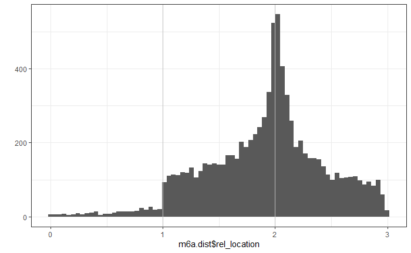

```r
qplot(m6a.dist$rel_location, geom="histogram", bins=75) +
  geom_vline(xintercept = 1:2, col = "grey") +
  theme_bw()
```

Although this works, it has to guess what fits where and is not ideal. instead we can use the full fledge ggplot2 to plot what we want

For example we could do a density histogram superimposed by a density plot.

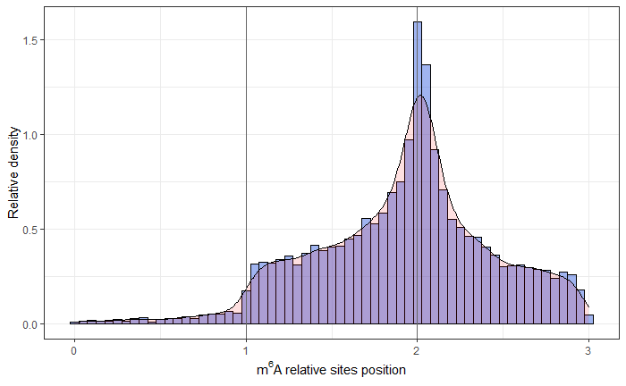

```r
ggplot(m6a.dist,aes(x=rel_location)) + # main function , defining what will be ploted
  geom_histogram(aes(y=stat(density)),binwidth=0.05, fill="royalblue", alpha=0.5, color="black")+   # histogram using a relative density instead of absolute counts
  geom_density(fill="red", alpha = 0.12)+   # superimpose a density plot
  geom_vline(xintercept = 1:2, col = "grey40") + # add lines at 5'-CDS and CDS-3'UTR junctions
  labs(y="Relative density", x=bquote(''*m^'6'*'A relative sites position'))+   # add custom label
  theme_bw()  #use a cleaner theme
```

#Still this graph is not perfect: All regions are represented with equal length. This is inacurate. for example 5’UTRs are usually shorter then CDS and 3’UTR.and we will need to rescale their position inorder to get an accurate representation of their distance to start and stop codon.

We can first look at the data to see what is the extent of the problem

```r
summary(data.frame(m6a.dist$utr5_size, m6a.dist$cds_size, m6a.dist$utr3_size), na.rm=T)
```

```
 m6a.dist.utr5_size m6a.dist.cds_size m6a.dist.utr3_size
 Min.   :    0.0    Min.   :   65     Min.   :    5
 1st Qu.:  115.0    1st Qu.:  890     1st Qu.:  512
 Median :  226.0    Median : 1442     Median : 1108
 Mean   :  329.5    Mean   : 1968     Mean   : 1641
 3rd Qu.:  408.0    3rd Qu.: 2396     3rd Qu.: 2189
 Max.   :14959.0    Max.   :26393     Max.   :17331
```

We can adjust the data to take respective length into account the median length of 226 for 5’UTR, 1442 for CDS and 1108 for 3’UTRs

#since the longest is the CDS, we will keep its relative length to 1 and adjust the UTRs.

```r
# first we find the scaling factor based on median length ratio for 5'UTR and 3'UTR
utr5.SF <- median(m6a.dist$utr5_size, na.rm = T)/median(m6a.dist$cds_size, na.rm = T)
utr3.SF <- median(m6a.dist$utr3_size, na.rm = T)/median(m6a.dist$cds_size, na.rm = T)

#we can now rescale the values in rel_location for 5'UTR and 3'UTR

m6a.dist<-m6a.dist %>%
  mutate( scaled_location = case_when(
                          rel_location < 1 ~ rescale(rel_location, to = c(1-utr5.SF, 1), from = c(0,1)),
                          rel_location > 2 ~ rescale(rel_location, to = c(2, 2+utr3.SF), from = c(2,3)),
                          rel_location >= 1 && rel_location <= 2 ~ rel_location))

summary(data.frame(m6a.dist$rel_location, m6a.dist$scaled_location), na.rm=T)
```

```
 m6a.dist.rel_location m6a.dist.scaled_location
 Min.   :0.002132      Min.   :0.8436
 1st Qu.:1.593043      1st Qu.:1.5930
 Median :1.981725      Median :1.9817
 Mean   :1.916481      Mean   :1.8911
 3rd Qu.:2.226809      3rd Qu.:2.1743
 Max.   :3.000000      Max.   :2.7684
```

#The data can now be ploted as before

using qplot: (as used in metaPlotR)

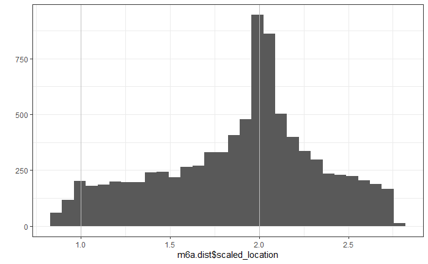

of ggplot:

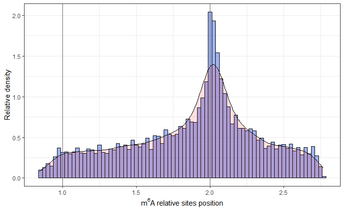

```r
ggplot(m6a.dist,aes(x=scaled_location)) + # main function , defining what will be ploted
  geom_histogram(aes(y=stat(density)),binwidth=0.025, fill="royalblue", alpha=0.5, color="black")+   # histogram using a relative density instead of absolute counts
  geom_density(fill="red", alpha = 0.12)+   # superimpose a density plot
  geom_vline(xintercept = 1:2, col = "grey40") + # add lines at 5'-CDS and CDS-3'UTR junctions
  labs(y="Relative density", x=bquote(''*m^'6'*'A relative sites position'))+   # add custom label
  theme_bw()  #use a cleaner theme
```

## different types of graph can be generated beyon histogram using qplot:

frequency polygon

[figure not shown]

```r
qplot(m6a.dist$scaled_location, geom="freqpoly") +
  geom_vline(xintercept = 1:2, col = "red") +
  theme_bw()
```

as shown in ggplot earlier, a smooth density plot:

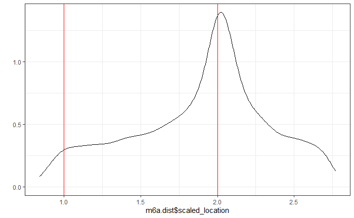

```r
qplot(m6a.dist$scaled_location, geom="density") +
  geom_vline(xintercept = 1:2, col = "red") +
  theme_bw()
```

a histogram with smaller bins:

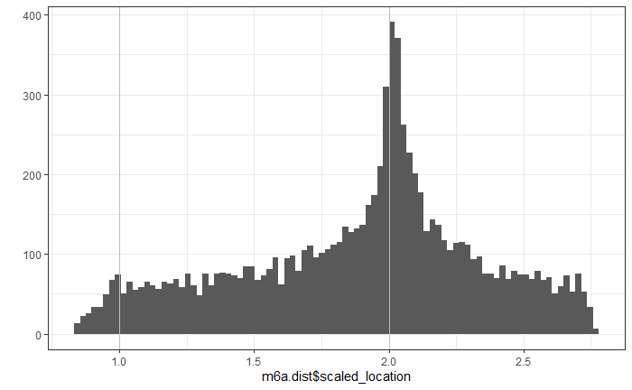

```r
# Histogram
qplot(m6a.dist$scaled_location, geom="histogram", bins=90) +
  geom_vline(xintercept = 1:2, col = "grey") +
  theme_bw()
```

# with more knowledge of ggplot, you can plot your data exactly as you like it.

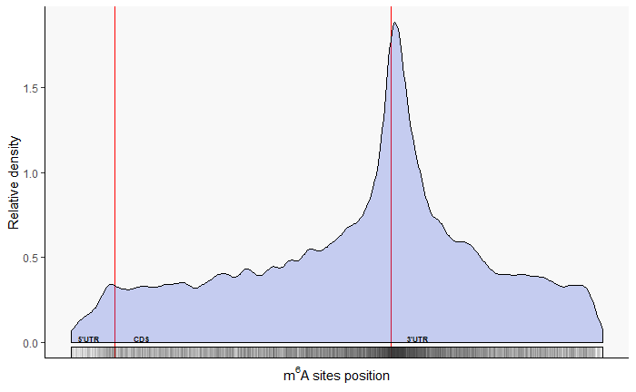

```r
text_5 <- textGrob("5'UTR", gp=gpar(fontsize=6, fontface="bold"))
text_3 <- textGrob("3'UTR", gp=gpar(fontsize=6, fontface="bold"))
text_cds <-textGrob("CDS", gp=gpar(fontsize=6, fontface="bold"))

ggplot(m6a.dist,aes(scaled_location)) +
  geom_vline(xintercept = 1:2, col = "red") +
  geom_density(outline.type = "full", fill="#2e47d9", alpha=0.25, adjust = 1/3)+
  geom_rug(alpha=0.05, outside = F, color="gray20")+
  geom_rect(xmax=max(m6a.dist$scaled_location),xmin=min(m6a.dist$scaled_location),ymax=-0.03,ymin=-0.09,colour="black",fill=NA)+
  labs(y="Relative density", x=bquote(''*m^'6'*'A sites position'))+
  scale_x_continuous(limits = c(min(m6a.dist$scaled_location), max(m6a.dist$scaled_location) ))+
  theme_classic()+
  theme(panel.background= element_rect(fill="#F8F8F8"),
        panel.grid.major = element_blank(),
        panel.grid.minor = element_blank(),
        axis.text.x=element_blank(),
        axis.ticks.x=element_blank())+
  annotation_custom(text_5,xmin=0.91,xmax=0.91,ymin=0.02,ymax=0.02) +
  annotation_custom(text_cds,xmin=1.10,xmax=1.10,ymin=0.02,ymax=0.02) +
  annotation_custom(text_3,xmin=2.1,xmax=2.1,ymin=0.02,ymax=0.02)+
  coord_cartesian(clip = "off")
```